# MEDB 5501, Module03

2024-09-03

## Topics to be covered

- What you will learn
  - The normal distribution
  - Normal probabilities and quantiles
  - Assessing normality
  - Using R to assess normality
  - Transformations
  - TBA

## The bell shaped curve

- Does your variation follow a bell shaped curve?
- Synonyms: normality, normal distribution
  - Values in the middle are most common
  - Frequencies taper off away from the center
  - Symmetry on either side

## Bell-shaped curve is a limit

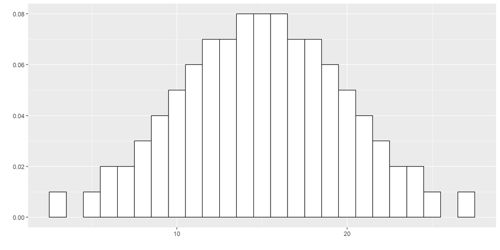

## Bell-shaped curve is a limit

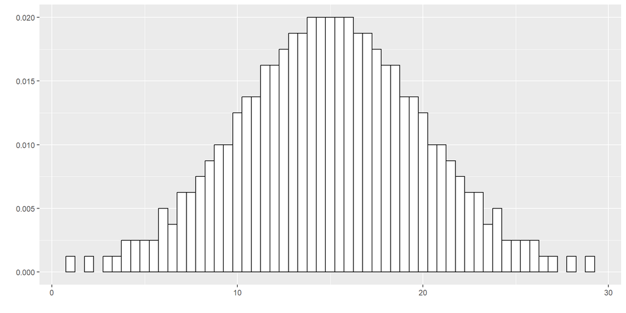

## Bell-shaped curve is a limit

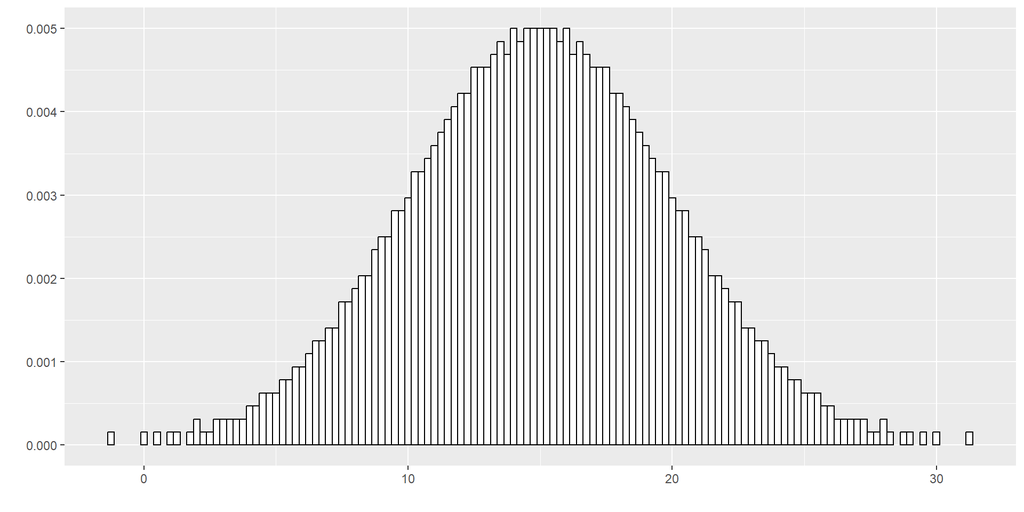

## Bell-shaped curve is a limit

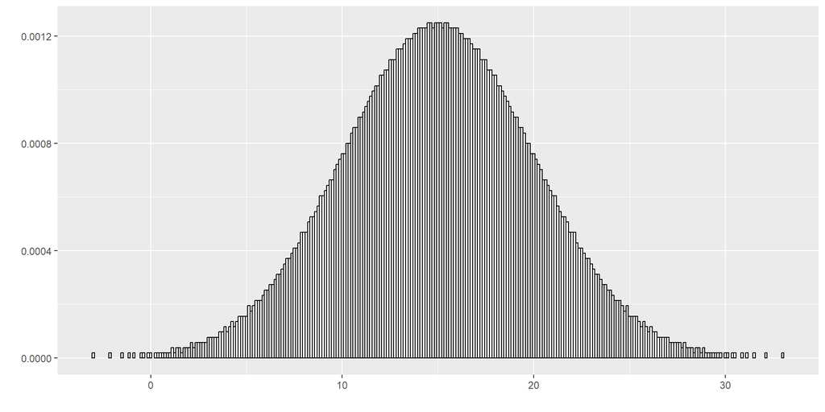

## Overview

The normal distribution is an important component of most statistical analyses. The formula for the normal distribution is quite complex,

but the shape is readily recognizable.

## Normal distribution with mu=2, sigma=1

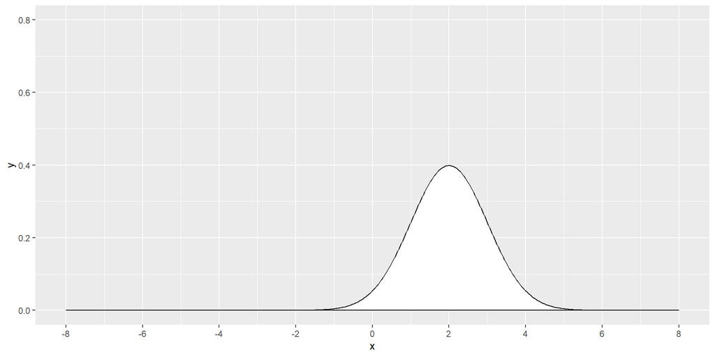

## Normal distribution with mu=-3, sigma=1

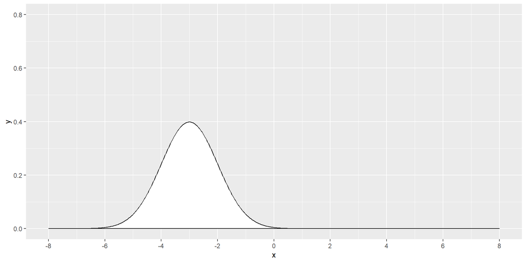

## Normal distribution with mu=1, sigma=1

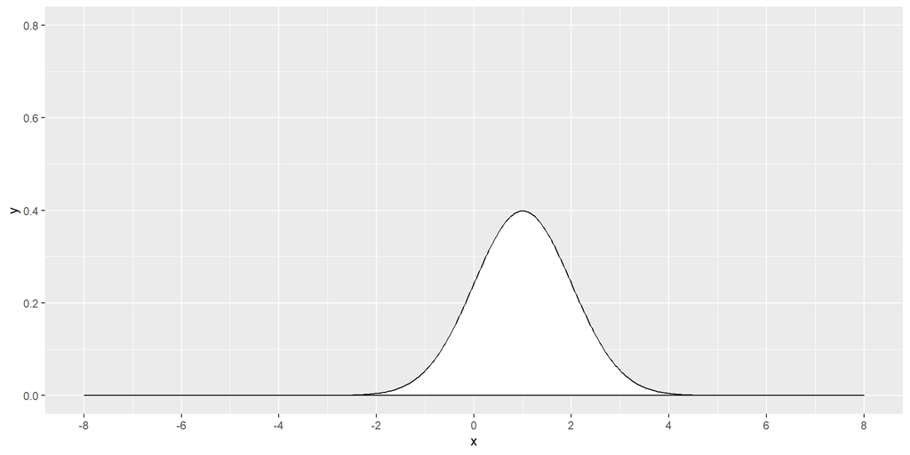

## Normal distribution with mu=1, sigma=2

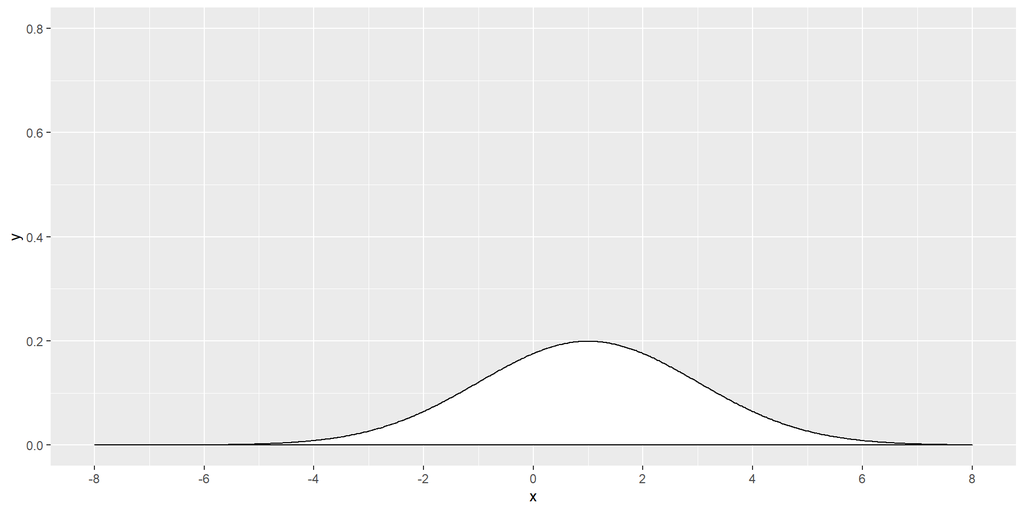

## Normal distribution with mu=1, sigma=0.5

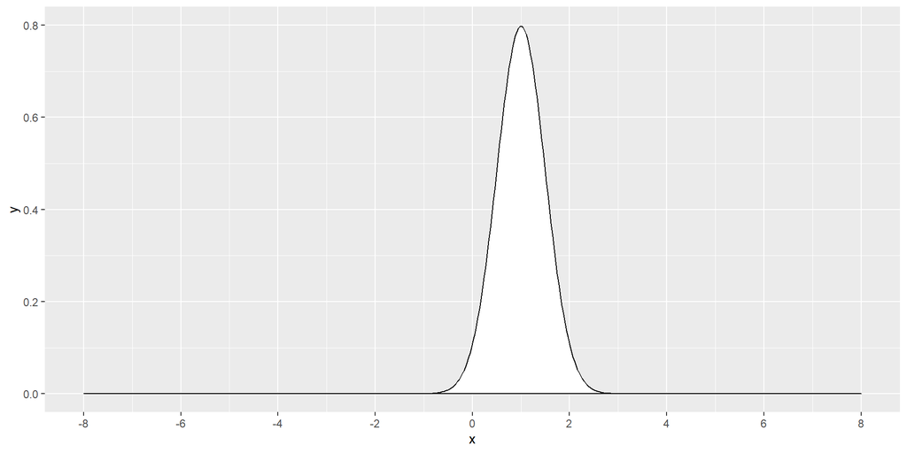

## Standard normal distribution (mu=0, sigma=1)

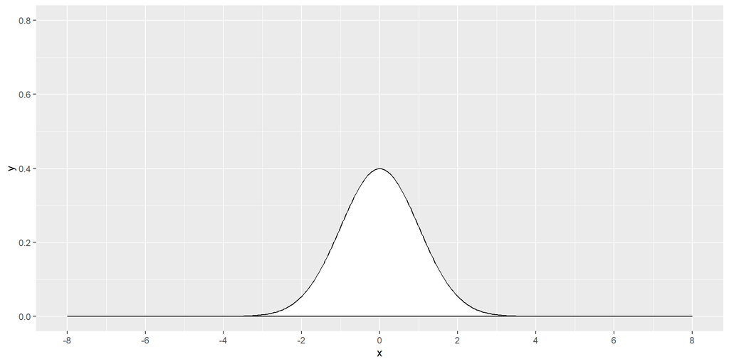

## Why concern yourself with the bell shaped curve?

- You can characterize individual observations
- You can characterize summary measures

## Break #1

- What you have learned
  - The normal distribution
- What’s coming next
  - Normal probabilities and quantiles

## simon-5501-03-normal-calculations.qmd, 1

```
---
title: "Normal probabilities and quantiles"
format:
  revealjs:
    slide-number: true
    embed-resources: true
editor: source
---

This program displays the standard normal curve along with various probabilities and quantiles. It was written by Steve Simon on 2024-09-01 and is placed in the public domain.
```

## simon-5501-03-normal-calculations.qmd, 2

````
## Load the tidyverse library

```{r setup}
#| message: false
#| warning: false
library(tidyverse)
```
````

## simon-5501-03-normal-calculations.qmd, 3

````
## Using R to draw the standard normal curve

use seq to calculate 100 evenly spaced values between -4 and +4 and dnorm to compute the bell curve at each point. Use geom_polygon to paint the area surrounded by the bell curve.

```{r standard-normal}
x <- seq(-4, 4, length=100)
y <- dnorm(x)
data.frame(x, y) |>
  ggplot(aes(x, y)) +
    geom_polygon(fill="white", color="black") -> normal_curve
normal_curve
```
````

## simon-5501-03-normal-calculations.qmd, 4

````
## P[Z < 1.5]

Use geom_vline and geom_label to draw a vertical reference line and add text to the normal curve. The pnorm function computes the standard normal probability.

```{r prob-1}
a <- 1.5
normal_curve +
  geom_vline(xintercept=a) +
  geom_label(x=a, y=0.4, label=a) +
  geom_label(x=a-0.5, y=0, label="Area = ?")
pnorm(1.5)
```
````

## simon-5501-03-normal-calculations.qmd, 5

````
## P[Z < -0.5]

```{r prob-2}
a <- -0.5
normal_curve +
  geom_vline(xintercept=a) +
  geom_label(x=a, y=0.4, label=a) +
  geom_label(x=a-0.5, y=0, label="Area = ?")
pnorm(-0.5)
```
````

## simon-5501-03-normal-calculations.qmd, 6

````
## P[Z > 1]

When you are calculating the probability on the right (probability greater than some number), use 1-pnorm.

```{r prob-3}
a <- 1
normal_curve +
  geom_vline(xintercept=a) +
  geom_label(x=a, y=0.4, label=a) +
  geom_label(x=a+0.5, y=0, label="Area = ?")
1- pnorm(1)
```
````

## simon-5501-03-normal-calculations.qmd, 7

````
## P[Z > -2]

```{r prob-4}
a <- -2
normal_curve +
  geom_vline(xintercept=a) +
  geom_label(x=a, y=0.4, label=a) +
  geom_label(x=a+0.5, y=0, label="Area = ?")
1- pnorm(-2)
```
````

## simon-5501-03-normal-calculations.qmd, 8

````
## P[-2.5 < Z < 2.5]

When you are calculating the probability between two values, compute pnorm of the larger value minus pnorm of the smaller value.

```{r prob-5a}
a <- 2.5
normal_curve +
  geom_vline(xintercept=-a) +
  geom_vline(xintercept= a) +
  geom_label(x=-a, y=0.4, label=-a) +
  geom_label(x= a, y=0.4, label= a) +
  geom_label(x=0, y=0, label="Area = ?")
pnorm(2.5)- pnorm(-2.5)
```
````

## simon-5501-03-normal-calculations.qmd, 9

````
## P[-0.5 < Z < 0.5]

```{r prob-6}
a <- 0.5
normal_curve +
  geom_vline(xintercept=-a) +
  geom_vline(xintercept= a) +
  geom_label(x=-a, y=0.4, label=-a) +
  geom_label(x= a, y=0.4, label= a) +
  geom_label(x=0, y=0, label="Area = ?")
pnorm(0.5) - pnorm(-0.5)
```
````

## simon-5501-03-normal-calculations.qmd, 10

````
## 25th percentile of a standard normal

Use qnorm to calculate quantiles of the standard normal distribution.

```{r quantile-1}
p <- 0.25
a <- qnorm(p)
normal_curve +
  geom_vline(xintercept=a) +
  geom_label(x=a, y=0.4, label="Quantile = ?") +
  geom_label(x=a-0.5, y=0, label=p)
qnorm(0.25)
```
````

## simon-5501-03-normal-calculations.qmd, 11

````
## 90th percentile of a standard normal

```{r quantile-2}
p <- 0.9
a <- qnorm(p)
normal_curve +
  geom_vline(xintercept=a) +
  geom_label(x=a, y=0.4, label="Quantile = ?") +
  geom_label(x=a-0.5, y=0, label=p)
qnorm(0.9)
```
````

## Break #2

- What you have learned
  - Normal probabilities and quantiles
- What’s coming next
  - Assessing normality

## Assessing normality

- No variable follows a perfect normal distribution
  - But many are close
- How to assess (approximate) normality
  - Histogram
  - Boxplot
  - Normal probability plot
- Avoid formal tests of normality

## Histogram

- Peak in the middle
- Roughly symmetric
- Falls off exponentially
- Warning!! Bar width can influence your interpretation

## Sample Boxplot

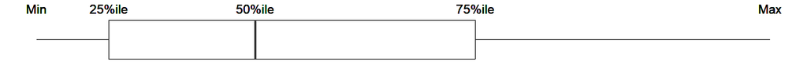

## What to look for in the boxplot

- Median halfway between 25th and 75th percentile.
- Whiskers are same size
- Whiskers not too short, not too long

## Constructing a normal probability plot, 1

- Calculate rank
- Divide by (n+1)
- Compute corresponding normal percentiles
- Compare these on a graph to the original data
- Roughly straight line implies normality

## Constructing a normal probability plot, 2

Use the rank function to assign 1 to the smallest value, 2 to the next smallest value, etc. up to n for the largest value.

```
   x r
1  7 4
2  3 2
3 23 9
4  2 1
5  5 3
6 13 6
7 11 5
8 17 7
9 19 8
```

## Constructing a normal probability plot, 3

Divide the rank by (n+1) to get evenly spaced percentages.

```
   x r pctile
1  7 4    0.4
2  3 2    0.2
3 23 9    0.9
4  2 1    0.1
5  5 3    0.3
6 13 6    0.6
7 11 5    0.5
8 17 7    0.7
9 19 8    0.8
```

## Constructing a normal probability plot, 4

Calculate percentiles from a normal distribution using the evenly spaced percentages.

```
   x r pctile          z
1  7 4    0.4 -0.2533471
2  3 2    0.2 -0.8416212
3 23 9    0.9  1.2815516
4  2 1    0.1 -1.2815516
5  5 3    0.3 -0.5244005
6 13 6    0.6  0.2533471
7 11 5    0.5  0.0000000
8 17 7    0.7  0.5244005
9 19 8    0.8  0.8416212
```

## Constructing a normal probability plot, 5

Plot the percentiles from the normal distribution to the original data. A reasonably straight line is evidence of normality.

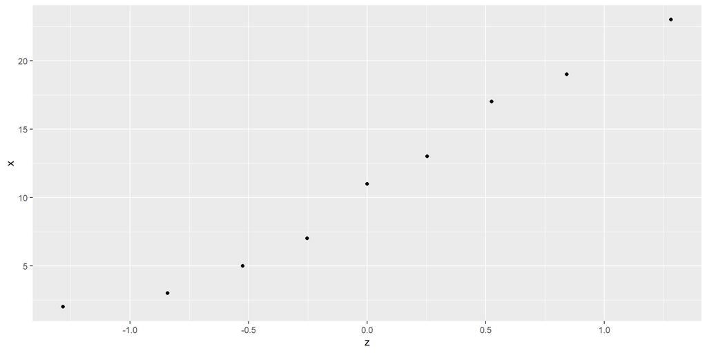

## Constructing a normal probability plot, 6

The qqnorm function will do all these steps for you automatically.

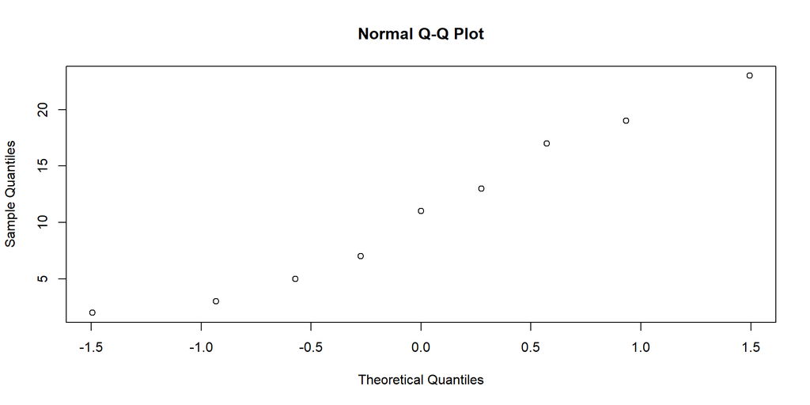

## Bimodal data, histogram

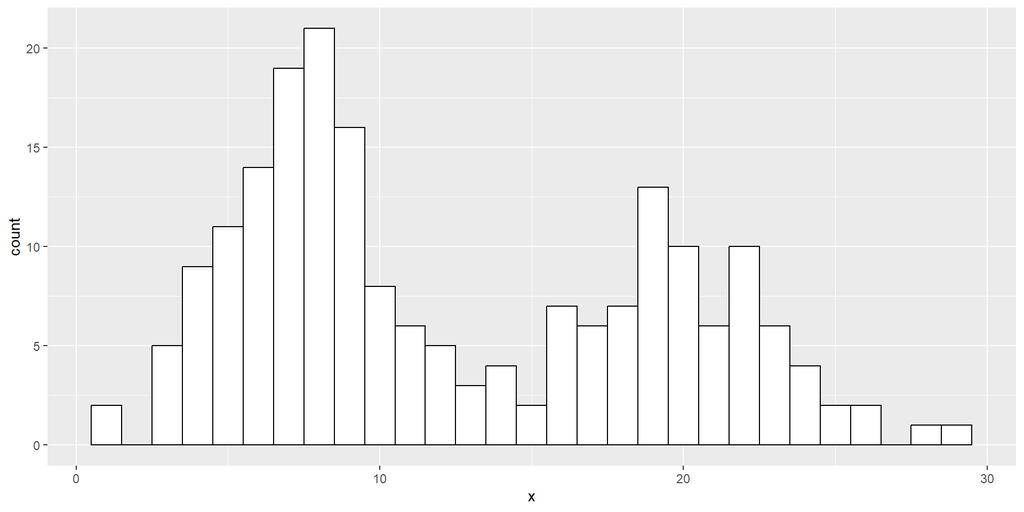

## Bimodal data, boxplot

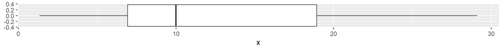

## Bimodal data, qq plot

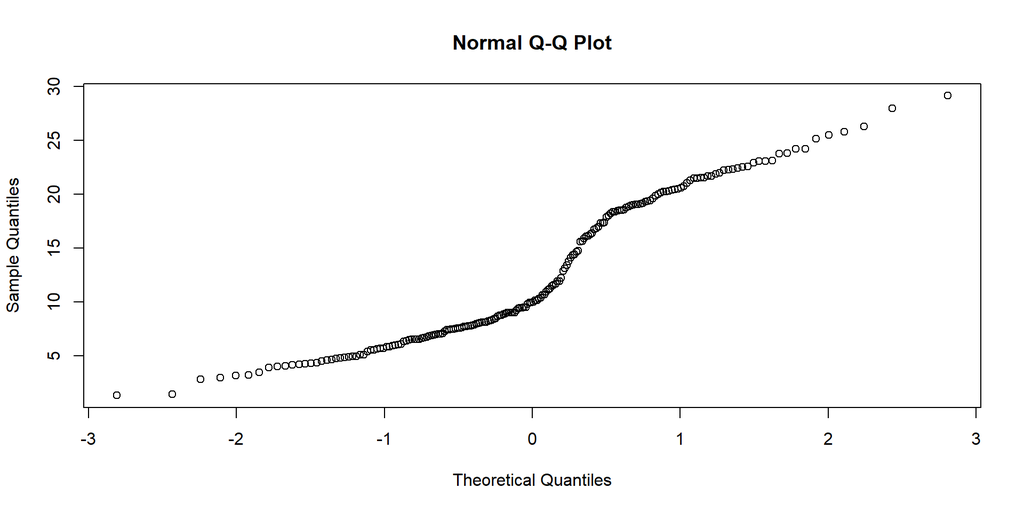

## Skewed data, histogram

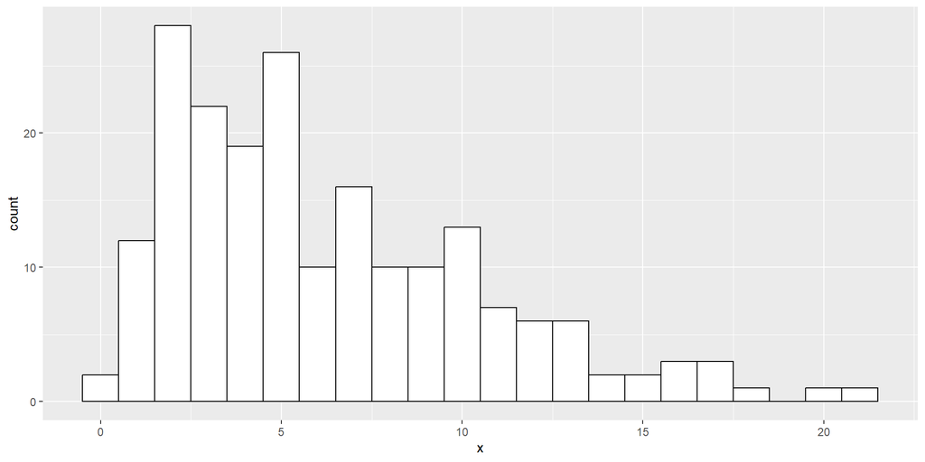

## Light-tailed data, histogram

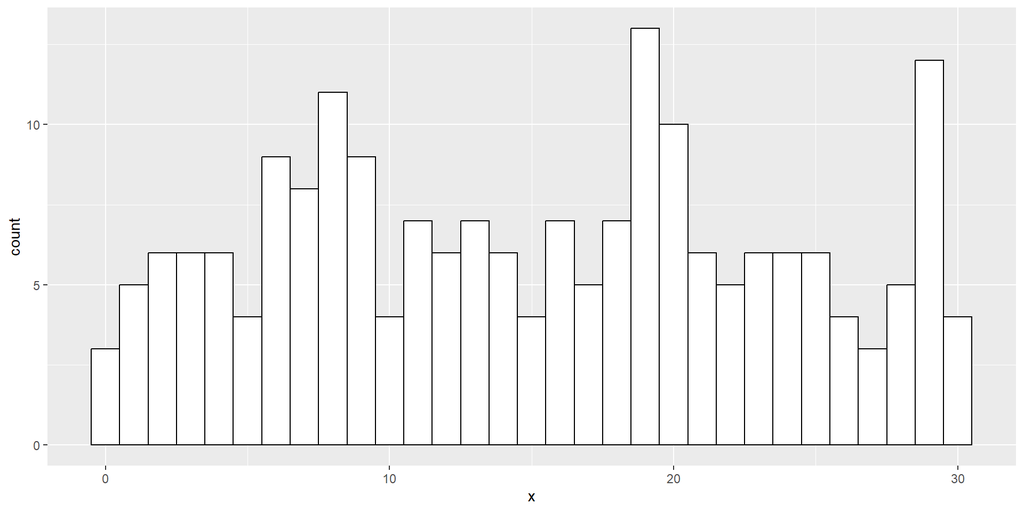

## Break #3

- What you have learned
  - Assessing normality
- What’s coming next
  - Using R to assess normality

## Data dictionary for fev, 1

```
---
data_dictionary: fev.txt
```

```
copyright: >
  The author of the jse article holds the copyright, but does not list
  conditions under which it can be used. Individual use for educational
  purposes is probably permitted under the Fair Use provisions of
  U.S. Copyright laws.
```

```
description: >
  Forced Expiratory Volume (FEV) in children
```

```
additional_description:
  http://jse.amstat.org/datasets/fev.txt
```

## Data dictionary for fev, 2

```
download_url:
  http://www.amstat.org/publications/jse/datasets/fev.dat.txt
```

```
format:
  space-delimited
```

```
varnames:
  not included
```

```
missing_value_code:
  not needed
```

```
size:
  rows: 654
  columns: 5
```

## Data dictionary for fev, 3

```
vars:
  age:
    scale: non-negative integer
    unit: years
```

```
  fev:
    label: Forced Expiratory Volume
    scale: non-negative real
    unit: liters
```

## Data dictionary for fev, 4

```
  ht:
    label: Height
    scale: non-negative integer
    unit: inches
```

```
  sex:
    value:
      Female: 0
      Male: 1
```

```
  smoke:
    value:
      Nonsmoker: 0
      Smoker: 1
---
```

## simon-5501-03-fev.qmd, 1

```
---
title: "Normality"
format:
  html:
    embed-resources: true
editor: source
---
```

## simon-5501-03-fev.qmd, 2

[output not shown]

## simon-5501-03-fev.qmd, 3

````
## Libraries

The tidyverse library is the only one you need for  this program.

```{r setup}
#| message: false
#| warning: false
library(tidyverse)
```
````

## simon-5501-03-fev.qmd, 4

````
## Reading the data

Here is the code to read the data and show a glimpse.

```{r read}
fev <- read_csv(
  file="../data/fev.csv",
  col_names=c(
    "age",
    "fev",
    "ht",
    "sex",
    "smoke"),
  col_types="nnncc")
  glimpse(fev)
```
````

## simon-5501-03-fev.qmd, 5

````
## Calculate mean and standard deviation for fev

```{r descriptive-fev}
fev |>
  summarize(
    fev_mean=mean(fev),
    fev_stdv=sd(fev))
```
````

## simon-5501-03-fev.qmd, 6

````
## Histogram for fev, wide bars

```{r histogram-fev-wide}
ggplot(
  data=fev,
  aes(x=fev)) +
  geom_histogram(
    binwidth=0.5,
    color="black",
    fill="white")
```
````

## simon-5501-03-fev.qmd, 7

````
## Histogram for fev, narrow bars

```{r histogram-fev-narrow}
ggplot(
  data=fev,
  aes(x=fev)) +
  geom_histogram(
    binwidth=0.1,
    color="black",
    fill="white")
```
````

## simon-5501-03-fev.qmd, 8

````
## Normal probability plot for fev

```{r qqplot-fev}
qqnorm(fev$fev)
```

```{r qqplot-log-fev}
qqnorm(log(fev$fev))
```
````

## Break #4

- What you have learned
  - Using R to assess normality
- What’s coming next
  - Transformations

## Break #5

- What you have learned
  - Transformations
- What’s coming next
  - TBA

## Summary

- What you have learned
  - The normal distribution
  - Normal probabilities and quantiles
  - Assessing normality
  - Using R to assess normality
  - Transformations
  - TBA